# C_elegans_enterococcus

Ken Youens-Clark

3/3/2018

## Introduction

Caenorhabditis elegans is a common soil-living nematode which has been shown to prefer eat Escherichia coli strain OP50 (Shtonda). This 2018 study compares C. elegans fed E. coli to groups fed 3 different species of enterococci, “natural commensals of the human gastrointestinal tract and important hospital-borne pathogens, with the majority of human enterococcal infections caused by two species, Enterococcus faecalis and Enterococcus faecium.” The purpose was to find which C. elegans genes were differentially expressed when fed four different bacteria.

The study used several C. elegans strains of the wild-type N2 Bristol. There are 13 samples each using 40-50 late L4-staged worms. The study used four groups:

- *C*: Four samples fed heat killed (HK) E. coli OP50 (because “live E. coli is pathogenic to C. elegans on BHI agar, the rich medium required for E. faecalis and E. faecium growth” [Ausubel])
- *Bs*: Three fed live B. subtilis PY79
- *Efs*: Three fed live E. faecalis MMH594
- *Efm*: Three fed live E. faecium E007

```r
dat = ReadAffy(celfile.path = "data")
num_samples = length(dat)
groups = c("C", "Bs", "Efs", "Efm")
fl <- factor(c(rep('0', 2), rep('1', 3), rep('2', 3), rep('3', 3), rep('0', 2)),
             labels=groups)

printf("There are %s features in %s samples\n", length(featureNames(dat)), num_samples)
```

```
## There are 22625 features in 13 samples
```

The level of gene expression was determined using the Affymetrix C. elegans Genome Array, a DNA microarray platform that measures 22,625 C. elegans genes (https://www.ncbi.nlm.nih.gov/geo/query/acc.cgi?acc=GPL200). The data was obtained from the NCBI Gene Expression Omnibus (GEO) under the accession “GSE95636” (https://www.ncbi.nlm.nih.gov/geo/query/acc.cgi?acc=GSE95636).

# Boxplots and MA Plots

An examination of the raw expression values shows the need for error correction:

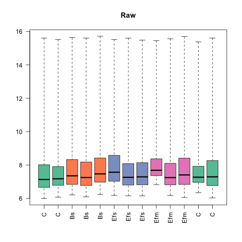

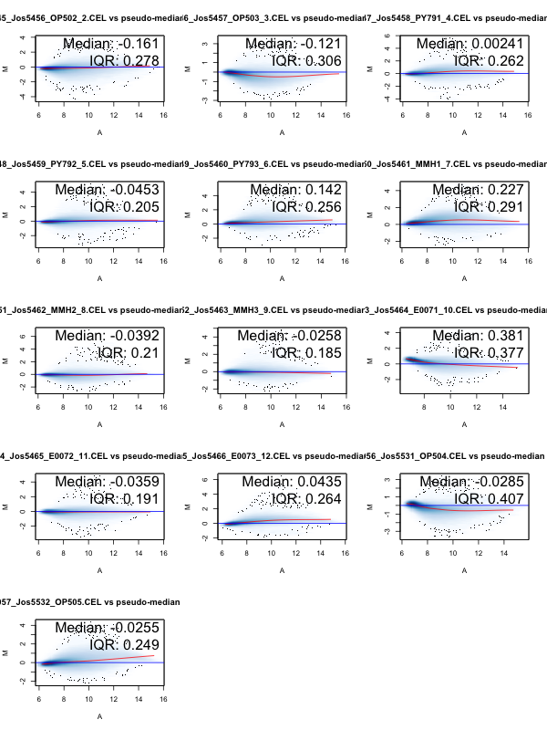

```r
palette(brewer_pal(type = "seq", palette = "Set2")(length(groups)))
png(filename = file.path(figures_dir, "raw-box-plot.png"))
boxplot(dat, names = fl, main = "Raw", las = 2, col = fl)
invisible(dev.off())

png(filename = file.path(figures_dir, "raw-ma-plot.png"), width = 600, height = 800)
par(mfrow = c(5,3))
MAplot(dat, plot.method = "smoothScatter")
invisible(dev.off())
```

The red lines on the MA plot deviate from the 0 horizontal. Using background correction and normalization, we can achieve much better results:

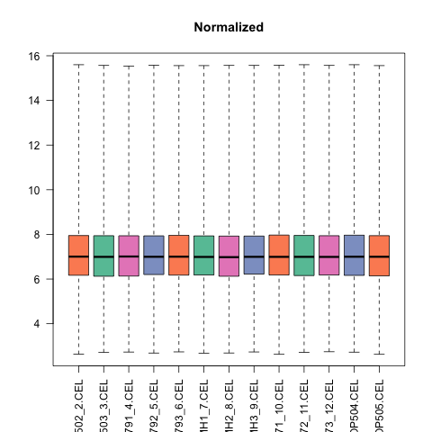

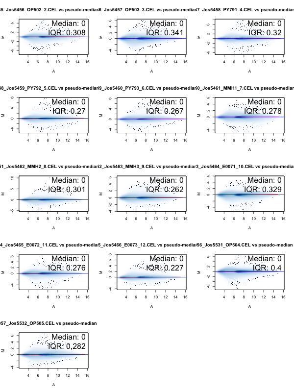

```r
dat.rmabg = bg.correct(dat, "rma")
dat.norm = normalize(dat.rmabg, "quantiles")
png(filename = file.path(figures_dir, "norm-box-plot.png"))
boxplot(dat.norm, main = "Normalized", las = 2, col = as.factor(groups))
invisible(dev.off())

png(filename = file.path(figures_dir, "norm-ma-plot.png"), width = 600, height = 800)
par(mfrow = c(5,3))
MAplot(dat.norm, plot.method = "smoothScatter")
```

These manual steps for error correction can be handled by the “expresso” function.

```r
eset <- expresso(dat,
                 bgcorrect.method = "rma",
                 normalize.method = "quantiles",
                 pmcorrect.method = "pmonly",
                 summary.method   = "medianpolish")
```

```
## background correction: rma
## normalization: quantiles
## PM/MM correction : pmonly
## expression values: medianpolish
## background correcting...done.
## normalizing...done.
## 22625 ids to be processed
## |                    |
## |####################|
```

Using the expresso-corrected data, we can create our experiment design and contrasts to find the differentially expressed genes. Below are the top 10 genes; the rest will be written to the “tables” directory.

```r
design <- model.matrix(~ 0 + fl)
colnames(design) = groups
fit <- lmFit(eset, design)
contrast.matrix <- makeContrasts(Efm-C, Bs-C, Efs-Bs, Efm-Efs, levels = design)
fit1 <- contrasts.fit(fit, contrast.matrix)
fit2 <- eBayes(fit1)

kable(topTable(fit2, n = 10, adjust = "fdr"))
```

|  | Efm…C | Bs…C | Efs…Bs | Efm…Efs | AveExpr | F | P.Value | adj.P.Val |
| --- | --- | --- | --- | --- | --- | --- | --- | --- |
| 189587_s_at | -0.1503985 | 5.9020673 | -6.1068772 | 0.0544114 | 5.504907 | 875.9594 | 0 | 0.0e+00 |
| 177104_at | -4.6571796 | -3.9987253 | -0.2077121 | -0.4507423 | 6.691346 | 744.0581 | 0 | 0.0e+00 |
| 174833_at | -1.3093708 | -3.5787612 | 2.3971603 | -0.1277699 | 10.752244 | 408.1111 | 0 | 0.0e+00 |
| 192417_at | -1.4560648 | -3.8795698 | 2.4862691 | -0.0627642 | 9.039587 | 245.2381 | 0 | 3.0e-07 |
| 192509_at | 0.4646494 | -2.8672568 | 7.6839819 | -4.3520757 | 8.981533 | 238.3956 | 0 | 3.0e-07 |
| 184694_at | 0.7014071 | 6.0277062 | -5.6649276 | 0.3386285 | 6.505575 | 221.6380 | 0 | 4.0e-07 |
| 189815_at | 2.7114365 | -0.2983555 | 2.2373584 | 0.7724336 | 7.063488 | 162.9834 | 0 | 1.8e-06 |
| 178403_at | 0.2446847 | 2.7018258 | -2.6970342 | 0.2398931 | 4.802688 | 162.0550 | 0 | 1.8e-06 |
| 186443_at | -3.4550685 | -3.6286270 | 1.0792466 | -0.9056881 | 8.646690 | 158.9541 | 0 | 1.8e-06 |
| 184993_at | -0.9846927 | -1.6587201 | 4.8339992 | -4.1599718 | 7.648667 | 141.9085 | 0 | 3.1e-06 |